# ERGM Tutorial

Alvin Zhou

2026-03-25

## 1) Load Packages and Set Data Path

```r
# clean up the environment
rm(list = ls())
library("tidyverse")
library("igraph")
library("network")
library("ergm")
library("intergraph")

DATA_DIR <- "network_data"
```

## 2) Import the Same Network in Multiple Ways

### Method 1A: CSV Files (node list + edge list)

```r
nodes_df <- read_csv(file.path(DATA_DIR, "ergm_node_list.csv"))
edges_df <- read_csv(file.path(DATA_DIR, "ergm_edge_list.csv"))

g_from_edgelist <- graph_from_data_frame(
  d = edges_df,
  directed = FALSE,
  vertices = nodes_df
)
```

### Method 1B: CSV Files (node list + adjacency matrix)

```r
adj_df <- read_csv(file.path(DATA_DIR, "ergm_adjacency_matrix.csv"))

adj_from_adjcsv <- adj_df |>
  select(-id) |>
  as.matrix()

rownames(adj_from_adjcsv) <- adj_df$id
colnames(adj_from_adjcsv) <- names(adj_df)[-1]

g_from_adjcsv <- graph_from_adjacency_matrix(
  adj_from_adjcsv,
  mode = "undirected",
  diag = FALSE
)

idx_csv <- match(V(g_from_adjcsv)$name, nodes_df$id)
V(g_from_adjcsv)$party <- nodes_df$party[idx_csv]
V(g_from_adjcsv)$gender <- nodes_df$gender[idx_csv]
V(g_from_adjcsv)$age <- nodes_df$age[idx_csv]
V(g_from_adjcsv)$outgoingness <- nodes_df$outgoingness[idx_csv]
```

### Method 2: One RDS File

```r
g_from_rds <- readRDS(file.path(DATA_DIR, "ergm_network_rds.rds"))

nodes_rds <- tibble(
  id = V(g_from_rds)$name,
  party = V(g_from_rds)$party,
  gender = V(g_from_rds)$gender,
  age = V(g_from_rds)$age,
  outgoingness = V(g_from_rds)$outgoingness
)
```

For the rest of this walkthrough, we use the RDS import.

```r
g <- g_from_rds

nodes <- tibble(
  id = V(g)$name,
  party = V(g)$party,
  gender = V(g)$gender,
  age = V(g)$age,
  outgoingness = V(g)$outgoingness
)
adj <- as.matrix(as_adjacency_matrix(g, sparse = FALSE))

# Calculate network summary statistics
num_nodes <- nrow(nodes)
num_edges <- sum(adj) / 2
net_density <- sum(adj) / (nrow(adj) * (nrow(adj) - 1))
```

**Network summary**: Our network has **60 nodes** and **194 edges**, with a density of **0.11**.

The network density tells us what fraction of all possible ties actually exist. In this case, about 11% of all possible connections between pairs of nodes are realized.

## 3) Basic igraph Visualization

```r
V(g)$label <- NA_character_

set.seed(1)
lay <- layout_with_fr(g)

party_cols <- c("Democrat" = "#0033CC", "Republican" = "#CC0000")
gender_cols <- c("Woman" = "#8000CC", "Man" = "#808080")

# Age coloring: dark grey (older) to bright orange (younger)
age_min <- min(V(g)$age)
age_max <- max(V(g)$age)
age_normalized <- (V(g)$age - age_min) / (age_max - age_min)
# Interpolate from dark grey (#404040) to bright orange (#FF8C00)
age_cols <- rgb(
  0.25 + 0.75 * age_normalized,  # R: 0.25 (dark) to 1.0 (bright)
  0.25 + 0.30 * age_normalized,  # G: 0.25 to 0.55
  0.25 - 0.25 * age_normalized   # B: 0.25 to 0.0
)

outgoing_sizes <- 4 + V(g)$outgoingness
```

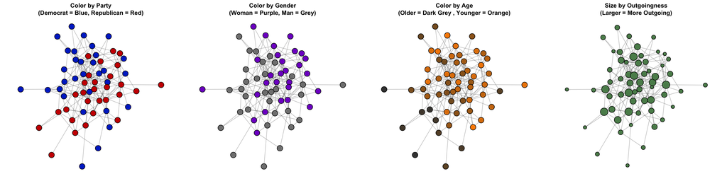

```r
par(mfrow = c(1, 4), mar = c(1, 1, 3, 1))
plot(
  g,
  layout = lay,
  vertex.color = party_cols[V(g)$party],
  vertex.size = 8,
  vertex.label = NA,
  edge.color = adjustcolor("grey30", alpha.f = 0.35),
  main = "Color by Party\n(Democrat = Blue, Republican = Red)"
)
plot(
  g,
  layout = lay,
  vertex.color = gender_cols[V(g)$gender],
  vertex.size = 8,
  vertex.label = NA,
  edge.color = adjustcolor("grey30", alpha.f = 0.35),
  main = "Color by Gender\n(Woman = Purple, Man = Grey)"
)
plot(
  g,
  layout = lay,
  vertex.color = age_cols,
  vertex.size = 8,
  vertex.label = NA,
  edge.color = adjustcolor("grey30", alpha.f = 0.35),
  main = "Color by Age\n(Older = Dark Grey , Younger = Orange)"
)
plot(
  g,
  layout = lay,
  vertex.color = "#5A8C5A",
  vertex.size = outgoing_sizes,
  vertex.label = NA,
  edge.color = adjustcolor("grey30", alpha.f = 0.35),
  main = "Size by Outgoingness\n(Larger = More Outgoing)"
)
```

**Now think:** What mechanisms might generate this structure? Think about:

- Does partisan sorting (homophily) appear stronger or weaker than you’d expect?
- How does gender or age similarity show up in ties?
- What role might outgoingness play in who connects to whom?
- Is triadic closure (transitivity; “my friends are also friends”) a trend here?

## 4) Build a statnet Network Object

**Why convert from igraph to statnet?**

So far we’ve used `igraph` for visualization and summary statistics—it’s great for those tasks. However, **ERGM fitting requires the `statnet` ecosystem**, specifically the `network` object class from the `network` package. Here’s why:

- The `ergm()` function (and the whole `ergm` package) is built around `network` objects, not `igraph` objects.
- `igraph` and `network` are fundamentally different graph representation systems with different APIs and underlying assumptions, think of it as Android vs. iOS.
- The `statnet` ecosystem (`network`, `ergm`, `ergm.ego`, `tergm`, etc.) all use `network` objects as their standard format.

The `intergraph` package bridges these two worlds: it lets us convert our `igraph` graph into a `network` object, preserving vertex attributes and edge structure. Once converted, we can fit ERGM models and use other `statnet` tools.

**Note:** After we fit the ERGM, we could convert back to `igraph` for visualization if desired, but the modeling step *requires* `statnet`/`network` objects.

```r
net1 <- intergraph::asNetwork(g)
set.vertex.attribute(net1, "party", nodes$party)
set.vertex.attribute(net1, "gender", nodes$gender)
set.vertex.attribute(net1, "age", nodes$age)
set.vertex.attribute(net1, "outgoingness", nodes$outgoingness)
```

## 5) Fit an ERGM Sequence

### Fitting Models

**ERGM Terms Explained:**

- **`nodematch("attr")`**: Tests for **homophily** on a categorical attribute. Positive coefficient means people with the same attribute value are more likely to be connected (e.g., Democrats connecting with Democrats).
- **`absdiff("attr")`**: Tests the effect of **absolute difference** on a continuous attribute. Negative coefficient means larger differences *reduce* the probability of a tie (e.g., people of similar ages are more likely to connect).
- **`gwesp()`**: Geometrically-weighted edgewise shared partners. Tests for **triadic closure** / clustering. This captures the tendency for “my friends’ friends become my friends.” Positive coefficient indicates strong clustering.
  - In `gwesp(0.5, fixed = TRUE)`, **`0.5`** is the decay parameter ($\alpha$).
  - It controls how strongly extra shared partners are weighted.
  - Smaller decay: higher shared-partner counts still matter a lot.
  - Larger decay: diminishing returns are stronger; going from 0 to 1 matters much more than from 4 to 5.
  - So `0.5` is a moderate choice that rewards closure but with diminishing returns.
  - **`fixed = TRUE`** means the decay value (`0.5`) is held fixed, not estimated from data.
  - Pros: simpler model, often more stable and faster.
  - Cons: you assume the decay shape instead of learning it.
  - If `fixed = FALSE`, ERGM also estimates the decay parameter (more flexible, but can be harder to fit/converge).

**Other common ERGM terms:**

- `triangle`: Count of triangles (simple triadic closure)
- `twopath`: Two-paths (paths of length 2), relates to clustering
- `sender("attr")`, `receiver("attr")`: Directional effects (for directed networks)
- `nodefactor("attr")`: Main effect of being in a particular category
- `nodecov("attr")`: Effect of a continuous attribute on degree
- `mutual`: Reciprocity (for directed networks)
- `isolates`: Number of isolated vertices

```r
m0 <- ergm(net1 ~ edges)
m1 <- ergm(net1 ~ edges + nodematch("party"))
m2 <- ergm(net1 ~ edges + nodematch("party") + nodematch("gender") + absdiff("age") + absdiff("outgoingness"))
m3 <- ergm(net1 ~ edges + nodematch("party") + nodematch("gender") + absdiff("age") + absdiff("outgoingness") + gwesp(0.5, fixed = TRUE))
```

### Model m3 Summary

```r
print(summary(m3))
```

```
## Call:
## ergm(formula = net1 ~ edges + nodematch("party") + nodematch("gender") +
##     absdiff("age") + absdiff("outgoingness") + gwesp(0.5, fixed = TRUE))
##
## Monte Carlo Maximum Likelihood Results:
##
##                       Estimate Std. Error MCMC % z value Pr(>|z|)
## edges                -2.796526   0.277015      0 -10.095  < 1e-04 ***
## nodematch.party       0.753419   0.152231      0   4.949  < 1e-04 ***
## nodematch.gender      0.510546   0.161701      0   3.157  0.00159 **
## absdiff.age          -0.050295   0.007847      0  -6.409  < 1e-04 ***
## absdiff.outgoingness -0.007410   0.048351      0  -0.153  0.87820
## gwesp.fixed.0.5       0.451139   0.101188      0   4.458  < 1e-04 ***
## ---
## Signif. codes:  0 '***' 0.001 '**' 0.01 '*' 0.05 '.' 0.1 ' ' 1
##
##      Null Deviance: 2454  on 1770  degrees of freedom
##  Residual Deviance: 1087  on 1764  degrees of freedom
##
## AIC: 1099  BIC: 1132  (Smaller is better. MC Std. Err. = 0.4392)
```

### How to Interpret m3 Coefficients

**Coefficient interpretation guide:**

- **Coefficients** are in log-odds.
- **exp(coef)** gives an odds ratio (multiplicative change in odds).
- **Positive coef** -> tie is more likely; **negative coef** -> tie is less likely.
- **For nodematch(‘party’) / nodematch(‘gender’):** positive means same-group pairs are more likely tied.
- **For absdiff(‘age’) / absdiff(‘outgoingness’):** negative means larger differences reduce tie odds.
- **For gwesp:** positive means stronger triadic closure / clustering tendency.

### Understanding the `edges` Term

The **`edges` coefficient is the baseline/intercept** of your ERGM. It captures the natural tendency toward tie formation before any attributes matter.

**What `edges` values mean:**

- **Potential range:** From $-\infty$ to $+\infty$ (log-odds scale), but typical social networks range from $-5$ to $+2$.
- **Interpretation:**
  - **Negative `edges`** (e.g., $-2.80$): Baseline network is **sparse**. Most random pairs are NOT connected. This is typical for social networks.
  - **Positive `edges`** (e.g., $+0.50$): Baseline network is **dense**. Most random pairs WOULD be connected. Very rare in real social networks; might indicate a very cohesive or small group.
  - **Zero `edges`**: Exactly 50/50 baseline odds-neither sparse nor dense.

**Important clarification on density:**

- If the model is only `~ edges`, then `edges = 0` implies tie probability $p=0.5$, so expected density is 0.5.
- In a fuller ERGM (like this one, with `nodematch`, `absdiff`, `gwesp`), `edges = 0` is only a baseline reference point. Other terms shift dyad probabilities, so overall density can still be far from 0.5.

**Examples:**

1. **Negative example (our data):** `edges = -2.80`
- Odds ratio: $e^{-2.80} \approx 0.061$
- Interpretation: 1/0.061 = 16.39. For any random pair, the baseline odds of a tie are about 16.39:1 *against* a connection. Our network is sparse.
- p-value: highly significant (< 1e-04), confirming this sparsity is real, not random noise.
2. **Positive example (hypothetical):** `edges = +1.00`
- Odds ratio: $e^{1.00} \approx 2.72$
- Interpretation: For any random pair, the baseline odds of a tie are about 2.7:1 *in favor* of a connection. A very dense network where people tend to connect unless there’s a reason not to.

```r
coef_tbl <- tibble(
  term = names(coef(m3)),
  log_odds = unname(coef(m3)),
  odds_ratio = exp(log_odds)
)

coef_tbl
```

```
## # A tibble: 6 × 3
##   term                 log_odds odds_ratio
##   <chr>                   <dbl>      <dbl>
## 1 edges                -2.80        0.0610
## 2 nodematch.party       0.753       2.12
## 3 nodematch.gender      0.511       1.67
## 4 absdiff.age          -0.0503      0.951
## 5 absdiff.outgoingness -0.00741     0.993
## 6 gwesp.fixed.0.5       0.451       1.57
```

### AIC Comparison

**How to interpret AIC:**

- **Lower AIC is better.** AIC balances model fit (likelihood) with model complexity (number of parameters).
- **Difference >10:** Strong evidence the lower-AIC model is better.
- **Difference 4-7:** Moderate evidence the lower-AIC model is better.
- **Difference <4:** Competing models have similar support; prefer the simpler one (fewer parameters).
- If AIC increases when you add a term, that term is not worth the added complexity.

```r
print(AIC(m0, m1, m2, m3))
```

```
##    df      AIC
## m0  1 1225.734
## m1  2 1201.290
## m2  5 1123.180
## m3  6 1099.098
```

### Goodness-of-Fit Diagnostics

**How to read GOF and assess model fit:**

GOF compares observed network statistics to those simulated from the fitted model:

- **Basics:** The table shows observed statistics (Obs), mean simulated (Mean Sim), and standard deviation (Std Dev Sim).
- **Boxplots:** Each box summarizes the distribution from simulated networks at each x-axis value.
  - Middle line = median simulated value
  - Box = interquartile range (25th to 75th percentile)
  - Whiskers = typical spread beyond the box (R boxplot rule)
  - Open circles = simulated outliers
- **Blue diamonds:** Mean (average) of the simulated values.
- **Black line/points:** Observed statistic from the real network.
- **Range/spread:** The vertical spread (box + whiskers) shows how much variation the model produces for that statistic.
  - Narrow range = model predicts that feature consistently
  - Wide range = model allows more variability
- **Good fit:** Observed statistics should fall within ~1-2 standard deviations of the simulated mean. If observed is much farther, the model is misspecifying that aspect.
- **Min, Max, Median, Mean:** Check if the model captures both average cases and extreme numbers.

**What should we look for?** No perfect fit exists, but we want:

- Most statistics within ~1 SD of observed
- Random scatter around the diagonal (no systematic bias)
- Worst fit usually happen at extreme nodes, which in some cases can be acceptable

```r
gof_m3 <- gof(m3)
print(gof_m3)
```

```
##
## Goodness-of-fit for model statistics
##
##                           obs       min      mean       max MC p-value
## edges                 194.000  157.0000  193.6900  232.0000       0.96
## nodematch.party       129.000   98.0000  128.6800  158.0000       0.96
## nodematch.gender      117.000   82.0000  114.2100  139.0000       0.90
## absdiff.age          2152.000 1631.0000 2145.1700 2802.0000       0.98
## absdiff.outgoingness  426.000  308.0000  427.8700  533.0000       0.96
## gwesp.fixed.0.5       191.524  127.3344  193.4219  272.9458       0.98
##
## Goodness-of-fit for minimum geodesic distance
##
##     obs min   mean max MC p-value
## 1   194 157 193.69 232       0.96
## 2   755 548 723.47 884       0.68
## 3   691 481 638.05 775       0.40
## 4   130  15 131.51 264       0.92
## 5     0   0  13.47  63       0.26
## 6     0   0   1.43  27       1.00
## 7     0   0   0.08   3       1.00
## 8     0   0   0.01   1       1.00
## Inf   0   0  68.29 284       0.64
##
## Goodness-of-fit for degree
##
##    obs min mean max MC p-value
## 0    0   0 1.10   4       0.66
## 1    4   0 2.30   6       0.40
## 2    6   1 3.72  10       0.28
## 3    1   1 5.07   9       0.10
## 4   11   2 6.11  13       0.04
## 5    5   2 6.48  12       0.80
## 6    6   1 6.77  14       1.00
## 7    4   1 6.42  13       0.40
## 8    5   1 6.21  14       0.84
## 9    6   0 4.83  12       0.68
## 10   1   0 3.91   9       0.24
## 11   5   0 2.64   8       0.28
## 12   3   0 1.83   6       0.56
## 13   2   0 1.16   5       0.68
## 14   0   0 0.69   4       1.00
## 15   1   0 0.38   4       0.58
## 16   0   0 0.23   2       1.00
## 17   0   0 0.07   1       1.00
## 18   0   0 0.06   1       1.00
## 19   0   0 0.01   1       1.00
## 20   0   0 0.01   1       1.00
##
## Goodness-of-fit for edgewise shared partner
##
##   obs min  mean max MC p-value
## 0  41  20 40.30  57       0.84
## 1  72  44 67.80  84       0.62
## 2  44  31 49.66  71       0.68
## 3  23   6 24.22  51       0.98
## 4  11   1  8.68  22       0.68
## 5   3   0  2.43  14       0.72
## 6   0   0  0.45   4       1.00
## 7   0   0  0.12   4       1.00
## 8   0   0  0.03   2       1.00
```

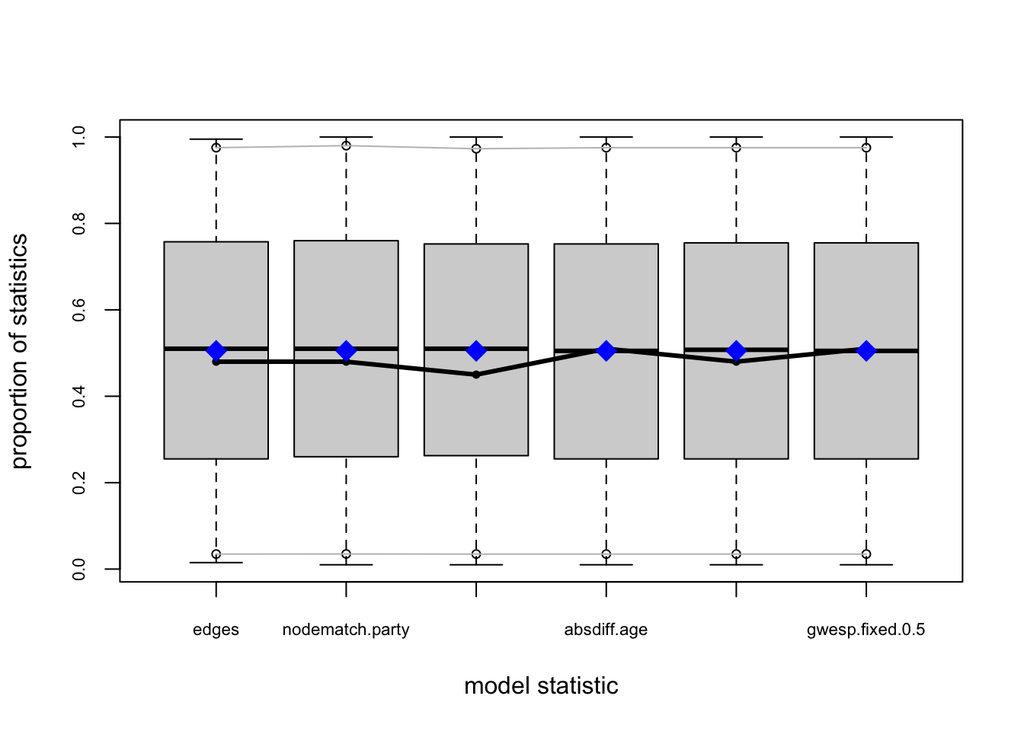

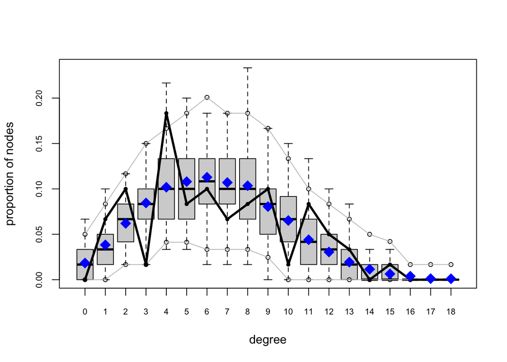

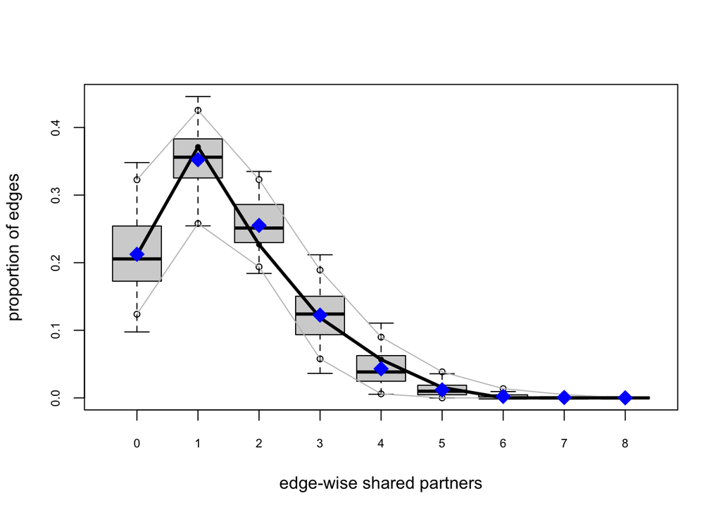

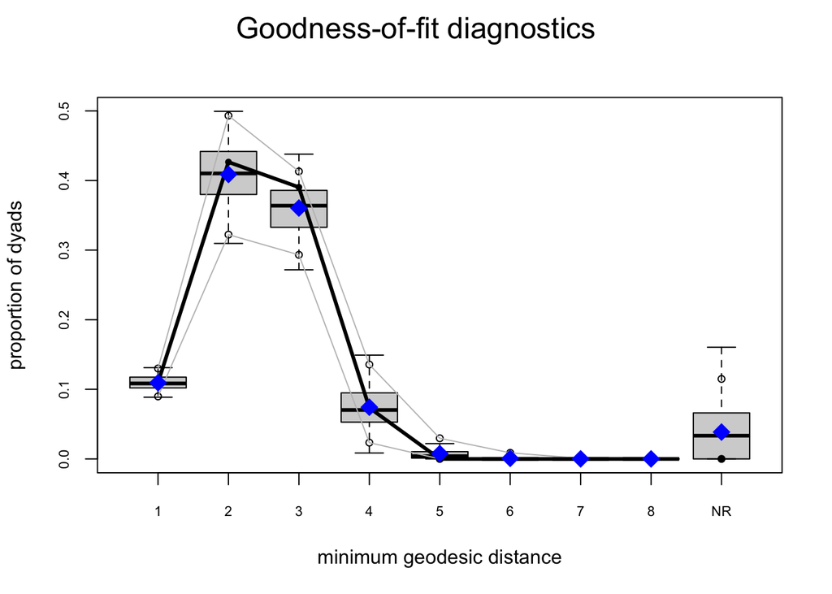

```r
plot(gof_m3)
```